# MFE PROJECT 2022-23

Gagan Singhal

2023-05-13

```r
suppressWarnings({
data <- read_excel("D:\\Sem 2\\Mathematics for Engineers - II\\Project\\1. Startup Datasets\\Final Project.xlsx")
is.na(data)
summary(data)
})
```

```
##       Date                        Startup_name         Vertical
##  Min.   :2015-01-02 00:00:00.00   Length:5195        Length:5195
##  1st Qu.:2016-04-27 00:00:00.00   Class :character   Class :character
##  Median :2017-11-28 00:00:00.00   Mode  :character   Mode  :character
##  Mean   :2018-07-03 22:48:12.47
##  3rd Qu.:2020-11-27 00:00:00.00
##  Max.   :2021-12-31 00:00:00.00
##
##      City           Investors_Name     Investment_Type        Amount
##  Length:5195        Length:5195        Length:5195        Min.   :1.270e+04
##  Class :character   Class :character   Class :character   1st Qu.:6.000e+05
##  Mode  :character   Mode  :character   Mode  :character   Median :2.300e+06
##                                                           Mean   :7.965e+07
##                                                           3rd Qu.:1.000e+07
##                                                           Max.   :1.500e+11
##                                                           NA's   :1342
```

#### Droping NA values from the dataset(data) using drop ‘na’ function

```r
startup<-data %>% drop_na()
summary(startup)
```

```
##       Date                        Startup_name         Vertical
##  Min.   :2015-01-02 00:00:00.00   Length:3103        Length:3103
##  1st Qu.:2016-03-07 12:00:00.00   Class :character   Class :character
##  Median :2017-08-21 00:00:00.00   Mode  :character   Mode  :character
##  Mean   :2018-04-03 22:37:51.60
##  3rd Qu.:2020-09-18 00:00:00.00
##  Max.   :2021-12-31 00:00:00.00
##      City           Investors_Name     Investment_Type        Amount
##  Length:3103        Length:3103        Length:3103        Min.   :1.270e+04
##  Class :character   Class :character   Class :character   1st Qu.:5.000e+05
##  Mode  :character   Mode  :character   Mode  :character   Median :2.000e+06
##                                                           Mean   :1.856e+07
##                                                           3rd Qu.:1.000e+07
##                                                           Max.   :3.900e+09
```

# Distribution of amount of investment made in several years

```r
startup$Year <- as.integer(format(as.Date(startup$Date), "%Y"))
investment_by_year <- aggregate(Amount ~ Year, data = startup, FUN = sum)
max_investment_year <- investment_by_year$Year[which.max(investment_by_year$Amount)]
investment_by_year$Percentage <- investment_by_year$Amount / sum(investment_by_year$Amount) * 100
labels <- paste(investment_by_year$Year, "(", round(investment_by_year$Percentage, 1), "%)", sep = "");labels
```

```
## [1] "2015(15%)"   "2016(6.8%)"  "2017(18.1%)" "2018(7.6%)"  "2019(16.4%)"
## [6] "2020(9.3%)"  "2021(26.7%)"
```

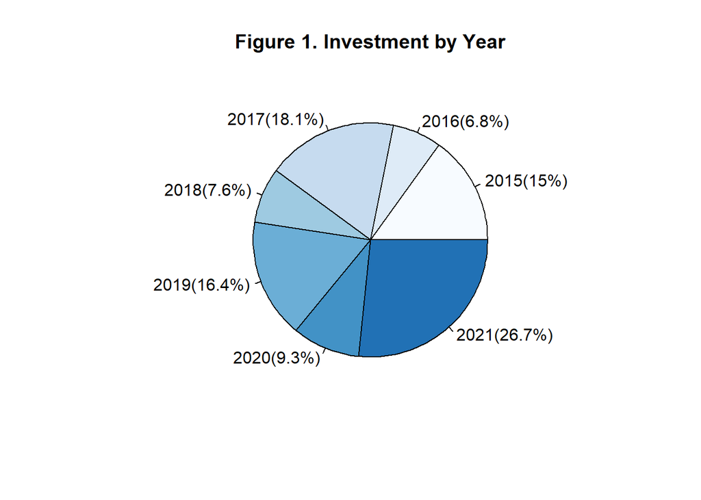

```r
pie(investment_by_year$Amount, labels = labels, main = "Figure 1. Investment by Year",col = brewer.pal(9, "Blues"))
```

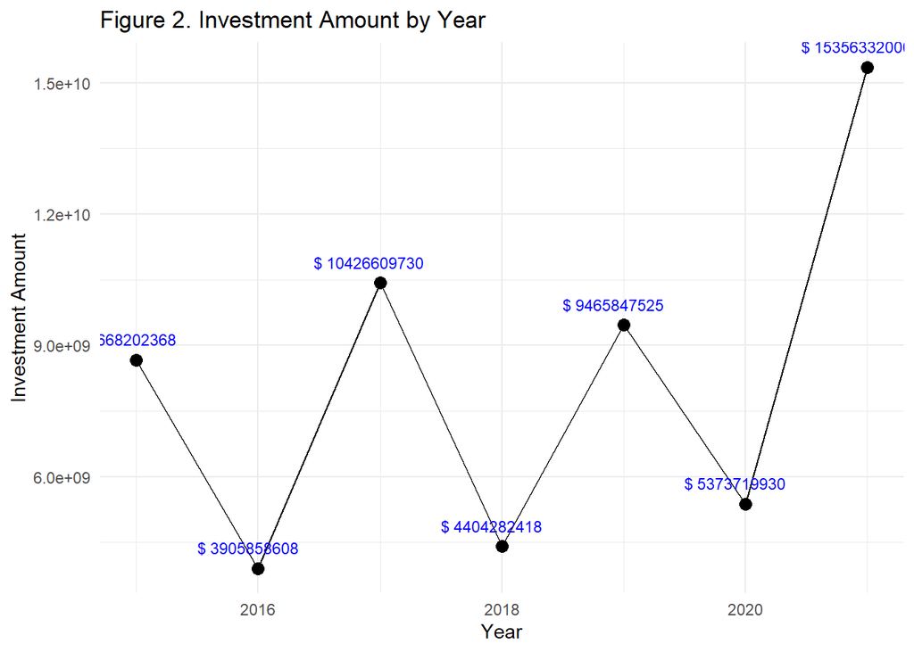

```r
ggplot(investment_by_year, aes(x = Year, y = Amount)) +
  geom_line() +
  labs(x = "Year", y = "Investment Amount", title = "Figure 2. Investment Amount by Year") +
  geom_text(aes(label = paste("$", Amount)), vjust = -1.2, hjust = +0.6, size = 3, color = "blue") +
  geom_point(size = 3, color = "black") +
  theme_minimal()
```

# Distribution of number of startups over several years

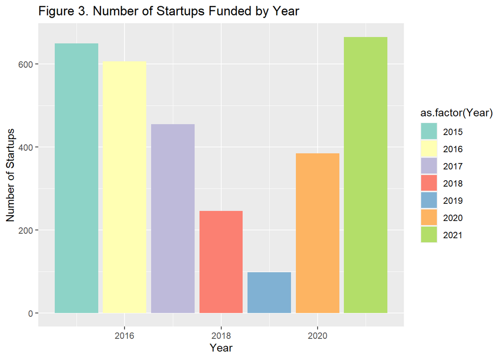

```r
startup$Year <- as.integer(substr(startup$Date, 1, 4))
startups_by_year <- aggregate(Startup_name ~ Year, data = startup, FUN = length)
max_funded_year <- startups_by_year$Year[which.max(startups_by_year$Startup_name)]
ggplot(startups_by_year, aes(x = Year, y = Startup_name, fill = as.factor(Year))) +
  geom_bar(stat = "identity") +
  labs(x = "Year", y = "Number of Startups", title = "Figure 3. Number of Startups Funded by Year") +
  scale_fill_brewer(palette = "Set3")
```

# Top 15 Startups that got multiple rounds of funding

```r
startup_rounds <- aggregate(Investment_Type ~ Startup_name, data = startup, FUN = function(x) length(unique(x)))
startup_multiple_rounds <- subset(startup_rounds, Investment_Type > 1);
top_15_startups <- head(startup_multiple_rounds[order(startup_multiple_rounds$Investment_Type, decreasing = TRUE), ], 15);top_15_startups
```

```
##         Startup_name Investment_Type
## 1979          Spinny               5
## 2171           Trell               5
## 211         BharatPe               4
## 324    Captain Fresh               4
## 901            Groww               4
## 980         HomeLane               4
## 1140       Jumbotail               4
## 1254         Licious               4
## 2089       Teachmint               4
## 2212         Ucademy               4
## 2262         Vedantu               4
## 143     Ather Energy               3
## 156      Avail Fince               3
## 173        Aye Fince               3
## 237  Biryani By Kilo               3
```

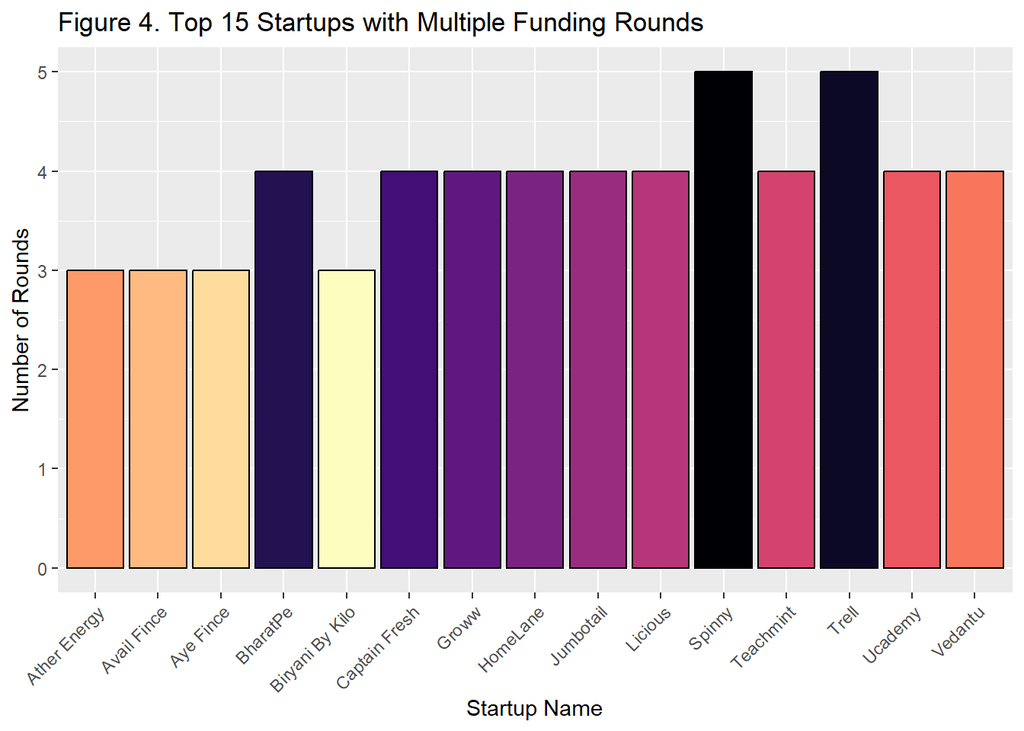

```r
ggplot(top_15_startups, aes(x = Startup_name, y = Investment_Type)) +
  geom_bar(stat = "identity", fill = magma(15), color = "black") +
  labs(x = "Startup Name", y = "Number of Rounds", title = "Figure 4. Top 15 Startups with Multiple Funding Rounds") +
  theme(axis.text.x = element_text(angle = 45, hjust = 1))
```

A bar chart that displays the number of funding rounds for each startup. Only the startups with multiple rounds will be shown in the chart. The x-axis represents the startup names, and the y-axis represents the number of rounds. The chart will help identify the startups that have received multiple rounds of funding.

# Top 15 vertical with highest number of startups

```r
top_verticals <- head(sort(table(startup$Vertical), decreasing = TRUE), 15);top_verticals
```

```
##
##                     Consumer-tech                        Technology
##                               620                               365
##                        E-Commerce                           Finance
##                               293                               259
##                           ED-TECH                        Healthcare
##                               190                               158
##                          Foodtech                         Logistics
##                               115                                76
##                        Automation                         Agri-Tech
##                                44                                41
##                                AI                    Transportation
##                                39                                35
##                              SaaS               Fashion & lifestyle
##                                32                                31
## Information Technology & Services
##                                30
```

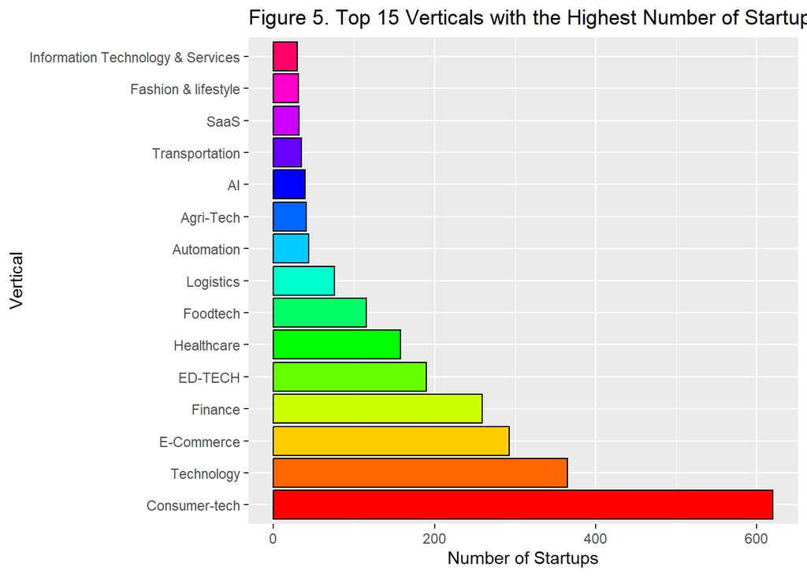

```r
ggplot(data.frame(vertical = names(top_verticals), count = as.numeric(top_verticals)),
       aes(x = count, y = reorder(vertical, -count))) +
  geom_bar(stat = "identity", fill = rainbow(15), color = "black") +
  labs(x = "Number of Startups", y = "Vertical", title = "Figure 5. Top 15 Verticals with the Highest Number of Startups") +
  theme(axis.text.y = element_text(hjust = +1.0))
```

The x-axis represents the number of startups, and the y-axis represents the verticals. The verticals are reordered based on the count of startups in descending order.

# Cities with highest number of startups

```r
top_cities <- head(sort(table(startup$City), decreasing = TRUE), 15)
top_startup <- subset(startup, startup$City %in% names(top_cities));top_cities
```

```
##
##  Bangalore     Mumbai  New Delhi    Gurgaon    Chennai       Pune  Hyderabad
##       1103        566        434        401        110         97         94
##      Noida  Ahemdabad     Jaipur    Kolkata Chandigarh        Goa     Indore
##         81         38         33         26          9          9          8
##      Thane
##          8
```

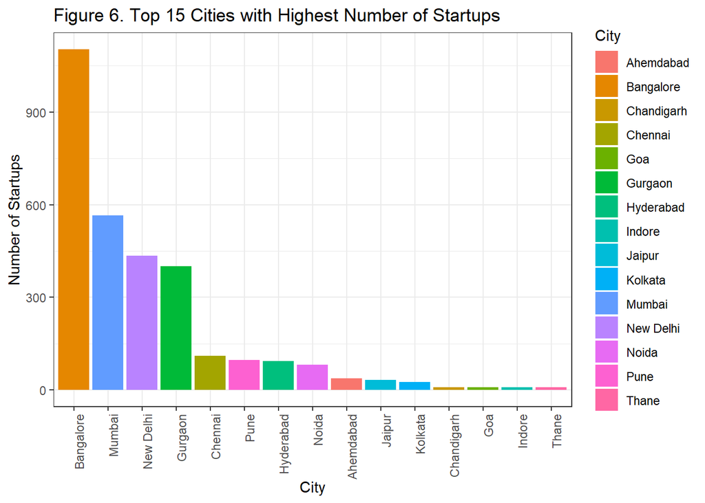

```r
ggplot(top_startup, aes(x = reorder(City, -table(City)[City]), fill = City)) +
  geom_bar() +
  labs(x = "City", y = "Number of Startups", title = "Figure 6. Top 15 Cities with Highest Number of Startups") +
  scale_fill_discrete(name = "City") +
  theme_bw() +
  theme(axis.text.x = element_text(angle = 90, hjust = 1))
```

The x-axis represents the cities, and the y-axis represents the number of startups. The bars are filled with colors based on the city variable to differentiate the bars. The bar plot displays the number of startups in each of the top 15 cities, allowing for easy comparison and identification of the city with the highest number of startups. The x-axis labels are angled for better readability when there are many cities.

# Most Popular Investment type

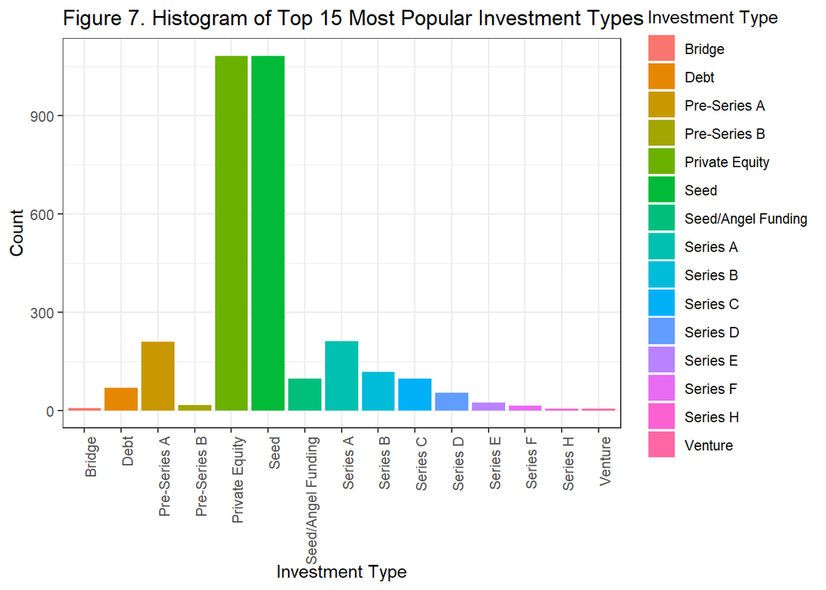

```r
top_investment_types <- head(sort(table(startup$Investment_Type), decreasing = TRUE), 15)
top_startup <- subset(startup, startup$Investment_Type %in% names(top_investment_types));
ggplot(top_startup, aes(x = Investment_Type, fill = Investment_Type)) +
  geom_bar() +
  labs(x = "Investment Type", y = "Count", title = "Figure 7. Histogram of Top 15 Most Popular Investment Types") +
  scale_fill_discrete(name = "Investment Type") +
  theme_bw() +
  theme(axis.text.x = element_text(angle = 90, hjust = 1))
```

The x-axis represents the investment types, and the y-axis represents the count of startups. The bars are filled with colors based on the investment type variable to differentiate the bars. The histogram displays the distribution of startups across the top 15 most popular investment types, allowing for easy comparison and identification of the investment type that is most commonly used. The x-axis labels are angled for better readability when there are many investment types.

## Seed type investment in different cities

```r
data_seed <- startup[startup$Investment_Type == "Seed", ]
a<-aggregate(Startup_name ~ City, data_seed, length);a
```

```
##                  City Startup_name
## 1           Ahemdabad           14
## 2            Amritsar            1
## 3      Andhra Pradesh            1
## 4           Bangalore          360
## 5            Bhilwara            1
## 6              Bhopal            1
## 7               Bihar            1
## 8          Chandigarh            5
## 9             Chennai           35
## 10          Faridabad            1
## 11                Goa            1
## 12            Gujarat            1
## 13            Gurgaon          117
## 14           Guwahati            1
```

[output cut: 30 more lines]

```r
summary(a)
```

```
##      City            Startup_name
##  Length:44          Min.   :  1.00
##  Class :character   1st Qu.:  1.00
##  Mode  :character   Median :  1.00
##                     Mean   : 24.61
##                     3rd Qu.:  5.25
##                     Max.   :360.00
```

## Private Equity type investment in different cities

```r
data_seed <- startup[startup$Investment_Type == "Private Equity", ]
a<-aggregate(Startup_name ~ City, data_seed, length);a
```

```
##             City Startup_name
## 1      Ahemdabad           12
## 2      Bangalore          391
## 3         Bhopal            1
## 4    Bhubaneswar            1
## 5          Bihar            1
## 6     Chandigarh            3
## 7        Chennai           36
## 8      Faridabad            1
## 9            Goa            2
## 10       Gurgaon          156
## 11     Hyderabad           41
## 12         India            1
## 13        Jaipur           22
## 14     Karnataka            3
## 15         Kochi            1
## 16       Kolkata            7
## 17       Lucknow            1
## 18   Maharashtra            3
## 19        Mumbai          221
## 20     New Delhi          139
## 21         Noida           31
## 22     Singapore            1
## 23         Surat            1
## 24    Tamil Nadu            4
## 25 Uttar Pradesh            1
## 26      Vadodara            1
```

```r
summary(a)
```

```
##      City            Startup_name
##  Length:26          Min.   :  1.00
##  Class :character   1st Qu.:  1.00
##  Mode  :character   Median :  3.00
##                     Mean   : 41.62
##                     3rd Qu.: 28.75
##                     Max.   :391.00
```

## Pre-Series A type of investment in different cities

```r
data_seed <- startup[startup$Investment_Type == "Pre-Series A", ]
a<-aggregate(Startup_name ~ City, data_seed, length);a
```

```
##         City Startup_name
## 1  Ahemdabad            4
## 2  Bangalore           71
## 3    Chennai            6
## 4        Goa            2
## 5    Gujarat            1
## 6    Gurgaon           24
## 7    Haryana            1
## 8     Indore            1
## 9     Kanpur            1
## 10     Kochi            1
## 11   Kolkata            2
## 12   Lucknow            1
## 13    Mumbai           35
## 14 New Delhi           32
## 15     Noida            7
## 16      Pune           18
## 17    Punjab            1
## 18     Thane            1
```

```r
summary(a)
```

```
##      City            Startup_name
##  Length:18          Min.   : 1.00
##  Class :character   1st Qu.: 1.00
##  Mode  :character   Median : 2.00
##                     Mean   :11.61
##                     3rd Qu.:15.25
##                     Max.   :71.00
```

## Series A type of investment in different cities

```r
data_seed <- startup[startup$Investment_Type == "Series A", ]
a<-aggregate(Startup_name ~ City, data_seed, length);a
```

```
##             City Startup_name
## 1      Bangalore           88
## 2     Chandigarh            1
## 3        Chennai           12
## 4      Faridabad            1
## 5            Goa            2
## 6        Gurgaon           27
## 7        Haryana            1
## 8      Karnataka            1
## 9         Mumbai           31
## 10     New Delhi           18
## 11         Noida            3
## 12          Pune           20
## 13     Singapore            1
## 14         Surat            1
## 15         Thane            4
## 16 Uttar Pradesh            1
```

```r
summary(a)
```

```
##      City            Startup_name
##  Length:16          Min.   : 1.00
##  Class :character   1st Qu.: 1.00
##  Mode  :character   Median : 2.50
##                     Mean   :13.25
##                     3rd Qu.:18.50
##                     Max.   :88.00
```

# Distribution of number of startups in different months

[figure not shown]

```r
startup$Date <- as.Date(startup$Date)
startup$Month <- format(startup$Date, "%B")
startup_count <- table(startup$Month)
highest_month <- names(startup_count)[which.max(startup_count)]
ggplot(startup, aes(x = Month, fill = Month)) +
  geom_bar() +
  labs(x = "Months", y = "Number of Startups", title = "Figure 8. Number of Startups Funded by Month") +
  scale_x_discrete(labels = c("Jan", "Feb", "Mar", "Apr", "May", "Jun", "Jul", "Aug", "Sep", "Oct", "Nov", "Dec")) +
  scale_fill_manual(values = c("#F78F6F", "#FFA500", "#FFD700", "#FF6347", "#FF4500", "#FF7F50",
                                        "#FF8C00", "#FFA07A", "#CD5C5C", "#FF7256", "#FF6347", "#FF0000")) +
                                          theme_bw() +
  theme(axis.text.x = element_text(angle = 90, hjust = 1))
```

# Calculate summary statistics

```r
num_startups <- nrow(startup)
num_investors <- startup %>% distinct(Investors_Name) %>% nrow()
total_investment <- sum(startup$Amount)
num_cities <- startup %>% distinct(City) %>% nrow()
```

# Print summary information

```r
cat("Summary of the Dataset:\n")
```

```
## Summary of the Dataset:
```

```r
cat("Number of Startups:", num_startups, "\n")
```

```
## Number of Startups: 3103
```

```r
cat("Number of Investors:", num_investors, "\n")
```

```
## Number of Investors: 2466
```

```r
cat("Total Investment:", total_investment, "\n")
```

```
## Total Investment: 57600852579
```

```r
cat("Number of Cities:", num_cities, "\n")
```

```
## Number of Cities: 53
```

# Calculate average investment amount by city

```r
avg_investment <- aggregate(Amount ~ City, data = startup, FUN = mean)
print(avg_investment)
```

```
##                  City     Amount
## 1           Ahemdabad 16888421.1
## 2            Amritsar   300000.0
## 3      Andhra Pradesh   500000.0
## 4           Bangalore 25532063.6
## 5             Bangkok  9000000.0
## 6            Bhilwara  1500000.0
## 7              Bhopal   265332.5
## 8         Bhubaneswar 23000000.0
## 9               Bihar  3164500.0
## 10         Chandigarh  5522222.2
## 11            Chennai  8730281.8
## 12          Faridabad 65750000.0
## 13        Gandhinagar  2000000.0
## 14                Goa 23427555.6
```

[output cut: 39 more lines]

# How does the number of investments vary by year?

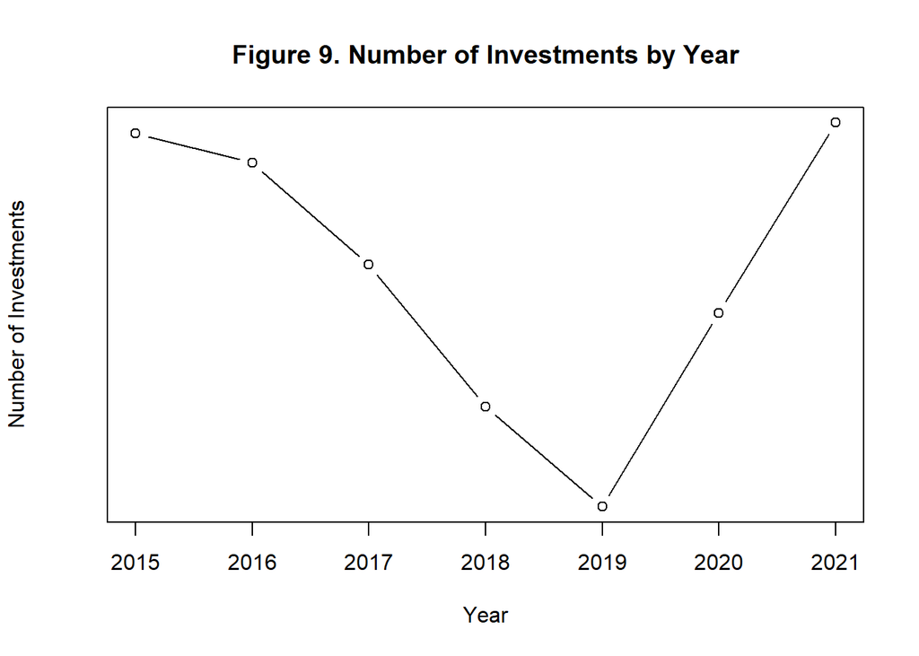

```r
startup$Date <- as.Date(startup$Date)
startup$Year <- format(startup$Date, "%Y")
investment_count <- table(startup$Year)
plot(as.numeric(names(investment_count)), investment_count, type = "b",
     xlab = "Year", ylab = "Number of Investments",
     main = "Figure 9. Number of Investments by Year")
```

A line plot with points that shows number of investments by year . The x-axis represents the year, and the y-axis represents the number of investments.

# Are there any outliers or anomalies in the investment amounts?

```r
q1 <- quantile(startup$Amount, 0.25)
q3 <- quantile(startup$Amount, 0.75)
iqr <- q3 - q1
upper <- q3 + 1.5 * iqr
lower <- q1 - 1.5 * iqr
outliers <- startup$Amount[startup$Amount > upper | startup$Amount < lower]

cat("Number of outliers in investment amounts:", length(outliers), "\n")
```

```
## Number of outliers in investment amounts: 420
```

```r
cat("Outliers in investment amounts:\n")
```

```
## Outliers in investment amounts:
```

```r
print(outliers)
```

```
##   [1]   50000000  100000000   56000000   31000000   50000000   26000000
##   [7]   60000000   80000000   40000000   30000000  110000000   50000000
##  [13]   25000000   30000000   75000000  150000000   25000000  400000000
##  [19]   50000000   25000000   35000000   40000000   50000000   28000000
##  [25]  100000000   85000000   35000000  137000000   50000000   40000000
##  [31]   50000000   60000000   30000000  100000000   30000000  100000000
##  [37]   30000000   25000000   60000000  100000000  700000000   50000000
##  [43]  500000000  100000000   30000000   90000000   25000000   30000000
##  [49]   63000000   50000000   25000000   40000000   45000000   40000000
##  [55]   60000000  225000000   75000000   37500000   30000000  680000000
##  [61]  100000000   36000000   25000000   50000000   34000000  500000000
##  [67]   25000000   52000000   27000000  120000000   30000000   25000000
##  [73]   70000000   30000000  180000000  100000000  145000000   35000000
##  [79]   35000000   30000000  200000000   75000000  150000000   25000000
##  [85]  100000000   30000000   50000000   60000000  100000000   25000000
```

[output cut: 55 more lines]

# A colorful line graph for the amount of investment made over time

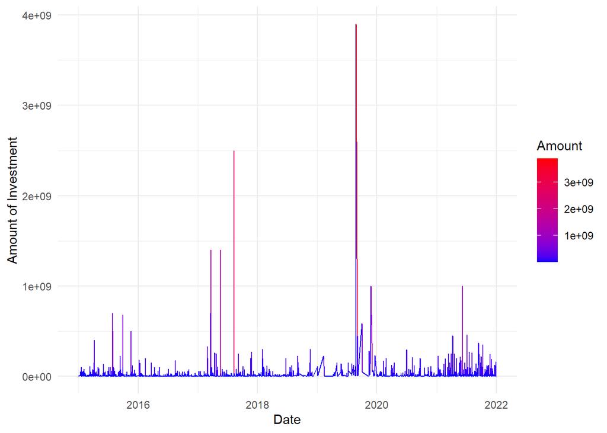

```r
ggplot(data = startup, aes(x = Date, y = Amount, color = Amount)) +
  geom_line() +
  scale_color_gradient(low = "blue", high = "red") +
  labs(x = "Date", y = "Amount of Investment") +
  theme_minimal()
```

Figure 10.

# How many investments were made in each vertical in a specific time period?

```r
startup$Date <- as.Date(startup$Date)
```

### From year 2015-2017:

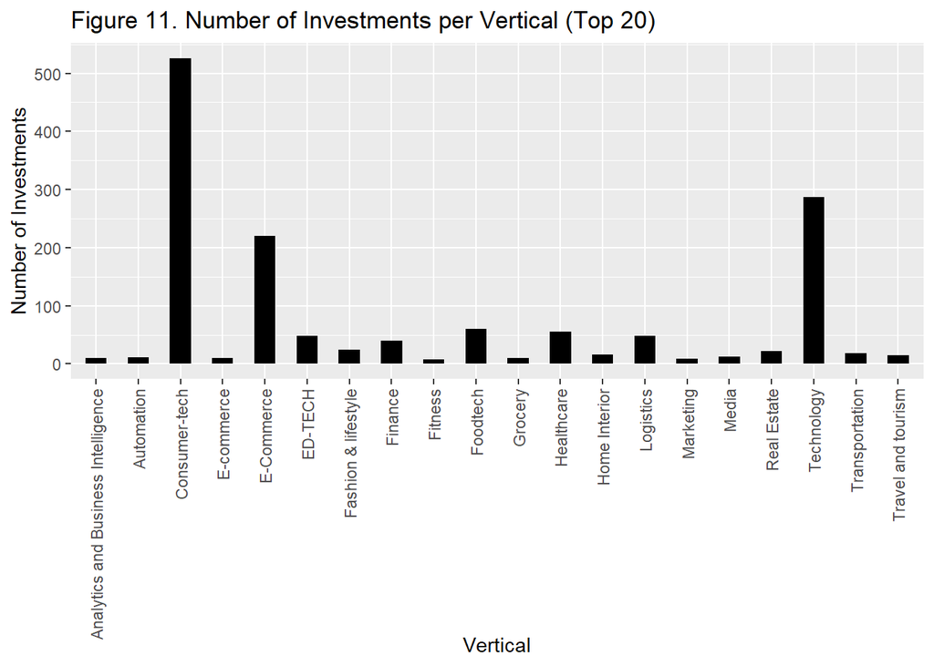

```r
start_date <- as.Date("2015-01-01")
end_date <- as.Date("2017-12-31")
investments_period <- subset(startup, Date >= start_date & Date <= end_date)
investments_count <- table(investments_period$Vertical)
sorted_investments <- sort(investments_count, decreasing = TRUE)
top_20_verticals <- names(sorted_investments)[1:20]
investments_top_20 <- subset(investments_period, Vertical %in% top_20_verticals)
investments_count_top_20 <- table(investments_top_20$Vertical)
ggplot(data = data.frame(Vertical = names(investments_count_top_20), Count = as.vector(investments_count_top_20)), aes(x = Vertical, y = Count)) +
  geom_bar(stat = "identity", fill = "black", width = 0.5) +
  labs(x = "Vertical", y = "Number of Investments", title = "Figure 11. Number of Investments per Vertical (Top 20)") +
  theme(axis.text.x = element_text(angle = 90, vjust = 0.5, hjust = 1))
```

A bar chart where the x-axis represents the verticals and the y-axis represents the number of investments.

### From year 2017-2019:

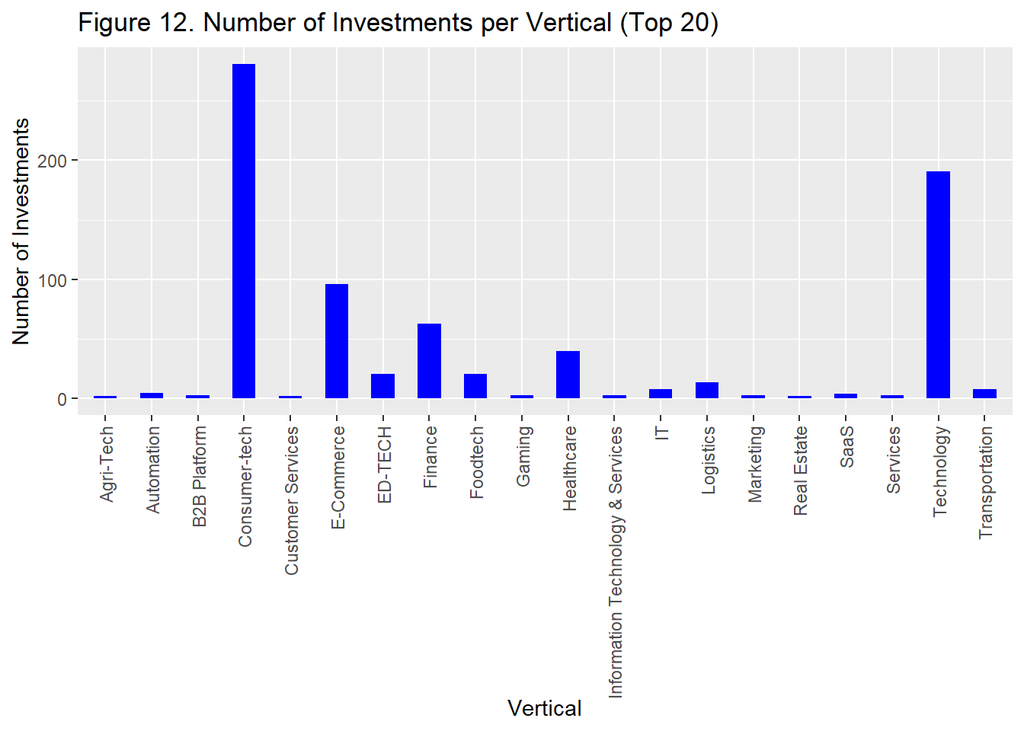

```r
start_date <- as.Date("2017-01-01")
end_date <- as.Date("2019-12-31")
investments_period <- subset(startup, Date >= start_date & Date <= end_date)
investments_count <- table(investments_period$Vertical)
sorted_investments <- sort(investments_count, decreasing = TRUE)
top_20_verticals <- names(sorted_investments)[1:20]
investments_top_20 <- subset(investments_period, Vertical %in% top_20_verticals)
investments_count_top_20 <- table(investments_top_20$Vertical)
ggplot(data = data.frame(Vertical = names(investments_count_top_20), Count = as.vector(investments_count_top_20)), aes(x = Vertical, y = Count)) +
  geom_bar(stat = "identity", fill = "blue", width = 0.5) +
  labs(x = "Vertical", y = "Number of Investments", title = "Figure 12. Number of Investments per Vertical (Top 20)") +
  theme(axis.text.x = element_text(angle = 90, vjust = 0.5, hjust = 1))
```

A bar chart where the x-axis represents the verticals and the y-axis represents the number of investments.

### From year 2019-2021:

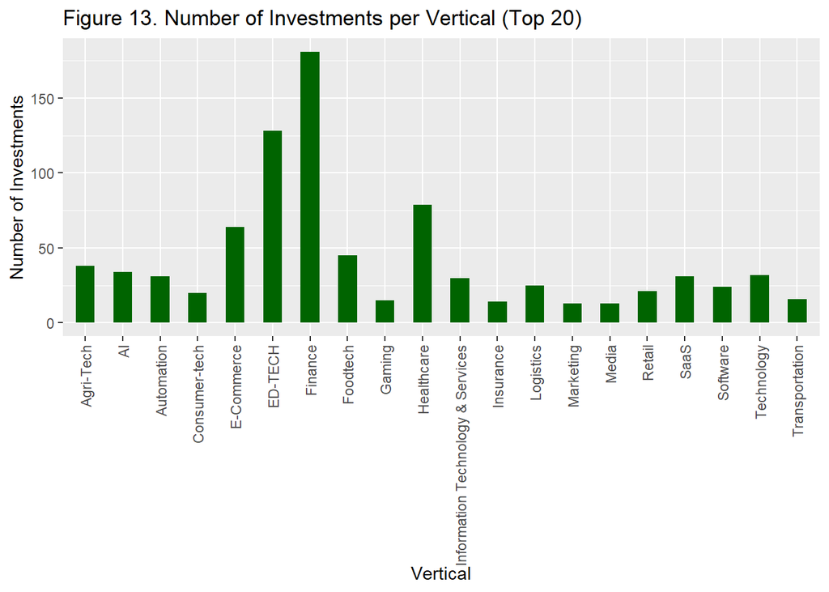

```r
start_date <- as.Date("2019-01-01")
end_date <- as.Date("2021-12-31")
investments_period <- subset(startup, Date >= start_date & Date <= end_date)
investments_count <- table(investments_period$Vertical)
sorted_investments <- sort(investments_count, decreasing = TRUE)
top_20_verticals <- names(sorted_investments)[1:20]
investments_top_20 <- subset(investments_period, Vertical %in% top_20_verticals)
investments_count_top_20 <- table(investments_top_20$Vertical)
ggplot(data = data.frame(Vertical = names(investments_count_top_20), Count = as.vector(investments_count_top_20)), aes(x = Vertical, y = Count)) +
  geom_bar(stat = "identity", fill = "darkgreen", width = 0.5) +
  labs(x = "Vertical", y = "Number of Investments", title = "Figure 13. Number of Investments per Vertical (Top 20)") +
  theme(axis.text.x = element_text(angle = 90, vjust = 0.5, hjust = 1))
```

A bar chart where the x-axis represents the verticals and the y-axis represents the number of investments.